# Black Friday Clustering Using K-means

# Problem Statement.

We are unsure on how the suppliers performed over Black Friday for Retailer 1. It would be useful to see how they performed to understand how much Retailer 1 is benefitting from these suppliers.

# Suggested solution.

Use K-means clustering to group together suppliers based on the quantity of sales vs the average value of their sales.

# 1. Overview

This notebook uses k-means clustering to group suppliers for Retailer 1 based on the quantity of sales vs the average value of their sales.

# 2. Load libraries

The Tidyverse collection of libraries includes all of the packages required to complete this analysis.

```r
#install.packages("tidyverse")
library(tidyverse)
```

# 3. Load data

Import the CSV file for Retailer 1 into R, and use ‘head’ to preview the new data.

```r
data <- read.csv('BF Clusterings.csv')
head(data)
```

```
    Supplier Average.Cost.... Count.of.Orders
1 Supplier 1        324.99000               2
2 Supplier 2         70.75471             119
3 Supplier 3        103.39000               5
4 Supplier 4        233.32333               3
5 Supplier 5         87.15172             373
6 Supplier 6        137.69400              10
```

# 4. Explore and transform the data

Looking at the data it is clear to see that the column headers can be renamed to make it easier for 3rd parties to understand the data.

```r
# The column headers are confusing due to the symbols I will rename them to replace the '.' with a space.
names(data) <- c("Supplier", "Average Order Cost (£)", "Count of Orders")
# I will check the the changes have worked as expected.
head(data)
```

```
    Supplier Average Order Cost (£) Count of Orders
1 Supplier 1              324.99000               2
2 Supplier 2               70.75471             119
3 Supplier 3              103.39000               5
4 Supplier 4              233.32333               3
5 Supplier 5               87.15172             373
6 Supplier 6              137.69400              10
```

# 5. Visualise the data

Now that my data is in the format I want, I can visualise this data in a scatter plot. This will give me a good chance to eyeball the data and get an idea of what I might expect to see from the final result.

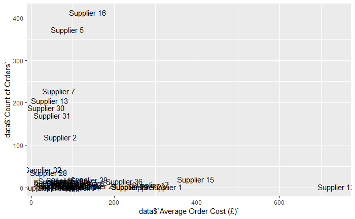

```r
qplot(x = data$`Average Order Cost (£)`, y = data$`Count of Orders`, label = data$Supplier, geom = "text")
```

# 6. Fine tuning k-means

Use wss to determine the optimal amount of clusters.

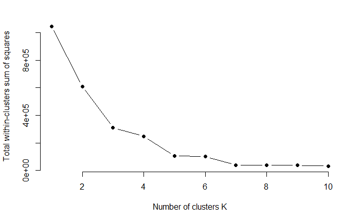

```r
kClustersMax <- 10
wss <- sapply(1:kClustersMax,
        function(k){kmeans(data[,2:3], k)$tot.withinss})
plot(1:kClustersMax, wss,
       type="b", pch = 19, frame = FALSE,
       xlab="Number of clusters K",
       ylab="Total within-clusters sum of squares")
```

# 7. Clustering

R has a built in `kmeans` function that I can use to create my clusters. [This documentation](https://stat.ethz.ch/R-manual/R-devel/library/stats/html/kmeans.html) explains how to use it.

```r
# Use the wss graph from step 6 to decide the optimum number of clusters.
kClusters <- 5
# Use the kmeans function and store the result in a variable
kMeansResult <- kmeans(data[,2:3], centers = kClusters)
# Create a new column in your dataset to show which cluster each ward belongs to
data$cluster <- kMeansResult$cluster
# Make sure your new cluster column is a factor, not an integer
data$cluster <- as.factor(data$cluster)
# Export clustered suppliers as CSV
write.csv(data, file = "Clustered BF.csv")
head(data)
```

```
    Supplier Average Order Cost (£) Count of Orders cluster
1 Supplier 1              324.99000               2       4
2 Supplier 2               70.75471             119       3
3 Supplier 3              103.39000               5       1
4 Supplier 4              233.32333               3       4
5 Supplier 5               87.15172             373       5
6 Supplier 6              137.69400              10       1
```

# 8. Visualise your clusters

Use qplot again to visualise the clustered data on the same scatterplot.

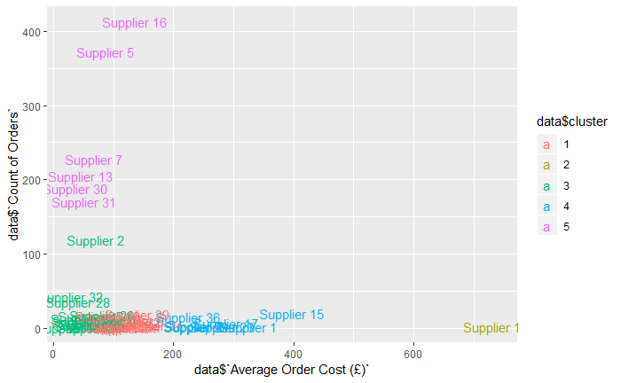

```r
qplot(x = data$`Average Order Cost (£)`, y = data$`Count of Orders`, label = data$Supplier, geom = "text", color = data$cluster)
```